# Final Project

```r
accuracy(U_hw_add, U_test)
```

```
##                         ME      RMSE       MAE         MPE      MAPE
## Training set -2.612404e-05 0.1382661 0.1066552  0.07502996  1.633474
## Test set      4.787735e-01 0.5598975 0.4787735 12.89745477 12.897455
##                   MASE      ACF1 Theil's U
## Training set 0.1408329 0.2245165        NA
## Test set     0.6321969 0.8387747  1.732663
```

```r
accuracy(U_hw_mult, U_test)
```

```
##                        ME      RMSE       MAE        MPE      MAPE
## Training set -0.008783273 0.1737138 0.1385591 -0.1213828  2.124184
## Test set      0.425407797 0.5260837 0.4311616 11.1675284 11.315560
##                   MASE      ACF1 Theil's U
## Training set 0.1829605 0.5084470        NA
## Test set     0.5693277 0.7304239  1.600939
```

```r
accuracy(U_hw_add_d, U_test)
```

```
##                       ME      RMSE        MAE        MPE     MAPE
## Training set -0.02660037 0.1426214 0.11499502 -0.4271753 1.749034
## Test set     -0.05551758 0.1036636 0.08531462 -1.5373984 2.291410
##                   MASE      ACF1 Theil's U
## Training set 0.1518453 0.1614497        NA
## Test set     0.1126538 0.2972248  0.310908
```

```r
accuracy(U_hw_mult_d, U_test)
```

```
##                       ME      RMSE       MAE        MPE     MAPE      MASE
## Training set -0.02117434 0.1550087 0.1242117 -0.3504702 1.909822 0.1640155
## Test set      0.16168723 0.2333294 0.1719450  3.9955623 4.282297 0.2270449
##                    ACF1 Theil's U
## Training set 0.07643835        NA
## Test set     0.41118854 0.6898783
```

#### Damped Holt-Winters Seasonal Additive method outperforms all of the other methods and has smallest values on all of the accuracy measures. Now let’s make true forecasts into the future 12, 24 and 36 month.

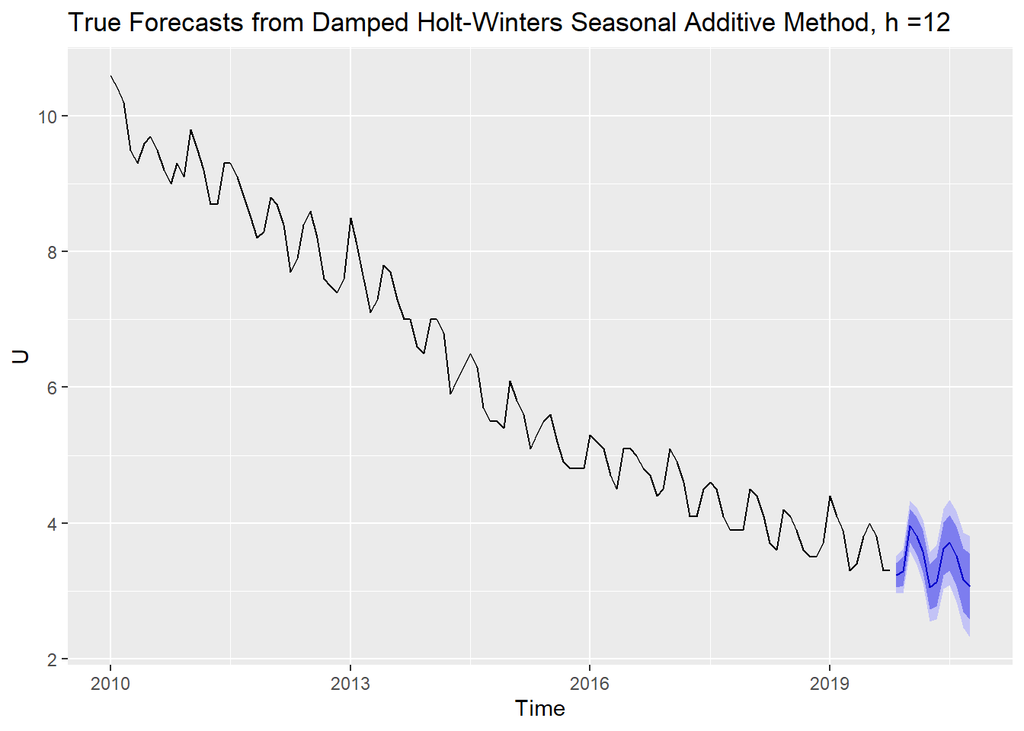

```r
U_hw_add_d12 = hw(U, seasonal = "additive", damped = TRUE, h = 12)
U_hw_add_d24 = hw(U, seasonal = "additive", damped = TRUE, h = 24)
U_hw_add_d36 = hw(U, seasonal = "additive", damped = TRUE, h = 36)


autoplot(U_hw_add_d12) + ggtitle("True Forecasts from Damped Holt-Winters Seasonal Additive Method, h =12")
```

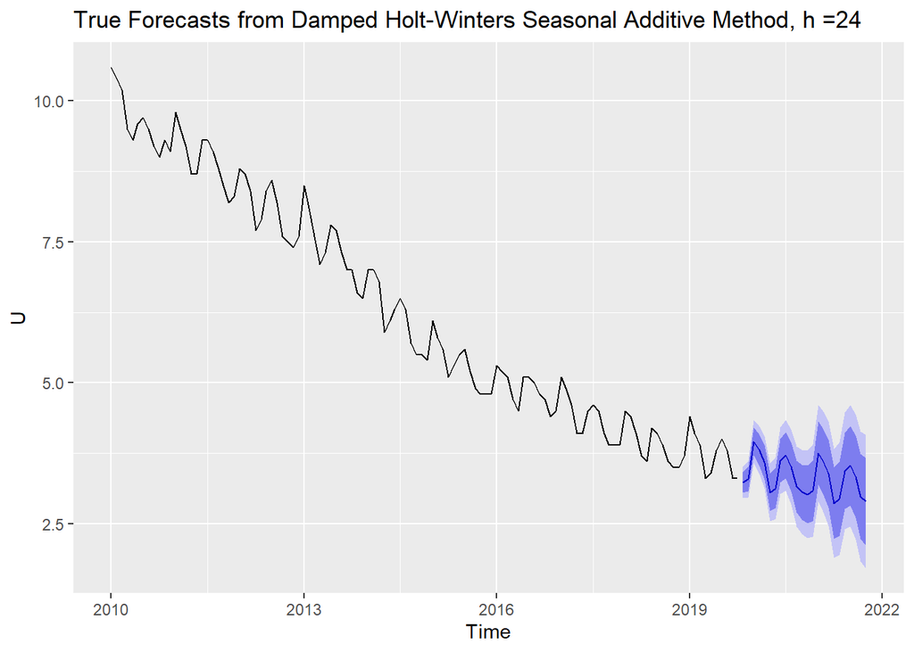

```r
autoplot(U_hw_add_d24) + ggtitle("True Forecasts from Damped Holt-Winters Seasonal Additive Method, h =24")
```

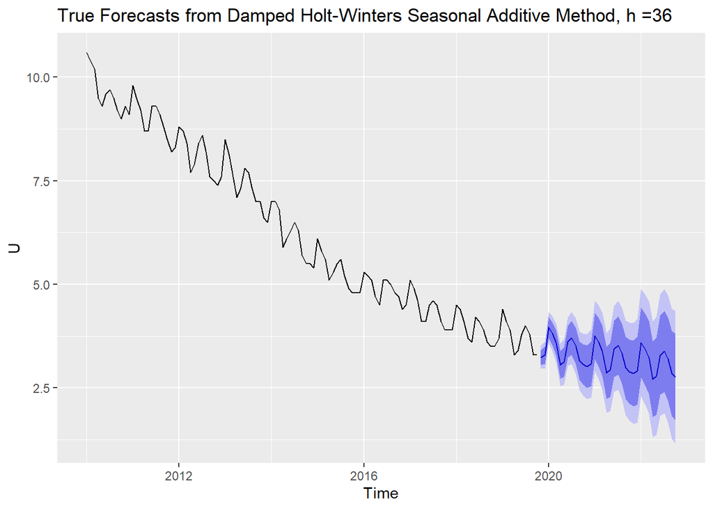

```r
autoplot(U_hw_add_d36) + ggtitle("True Forecasts from Damped Holt-Winters Seasonal Additive Method, h =36")
```

```r
U_hw_add_d12
```

```
##          Point Forecast    Lo 80    Hi 80    Lo 95    Hi 95
## Nov 2019       3.234490 3.054102 3.414879 2.958610 3.510371
## Dec 2019       3.291495 3.076496 3.506494 2.962683 3.620307
## Jan 2020       3.958148 3.711453 4.204843 3.580860 4.335436
## Feb 2020       3.806867 3.530363 4.083371 3.383990 4.229743
## Mar 2020       3.585689 3.280693 3.890685 3.119238 4.052140
## Apr 2020       3.055399 2.722876 3.387922 2.546849 3.563949
## May 2020       3.129467 2.770148 3.488786 2.579937 3.678998
## Jun 2020       3.622124 3.236580 4.007667 3.032486 4.211761
## Jul 2020       3.710680 3.299367 4.121993 3.081632 4.339729
## Aug 2020       3.510054 3.073341 3.946766 2.842159 4.177948
## Sep 2020       3.159753 2.697945 3.621560 2.453479 3.866026
## Oct 2020       3.061161 2.574515 3.547807 2.316900 3.805422
```

```r
U_hw_add_d24
```

```
##          Point Forecast    Lo 80    Hi 80    Lo 95    Hi 95
## Nov 2019       3.234490 3.054102 3.414879 2.958610 3.510371
## Dec 2019       3.291495 3.076496 3.506494 2.962683 3.620307
## Jan 2020       3.958148 3.711453 4.204843 3.580860 4.335436
## Feb 2020       3.806867 3.530363 4.083371 3.383990 4.229743
## Mar 2020       3.585689 3.280693 3.890685 3.119238 4.052140
## Apr 2020       3.055399 2.722876 3.387922 2.546849 3.563949
## May 2020       3.129467 2.770148 3.488786 2.579937 3.678998
## Jun 2020       3.622124 3.236580 4.007667 3.032486 4.211761
## Jul 2020       3.710680 3.299367 4.121993 3.081632 4.339729
## Aug 2020       3.510054 3.073341 3.946766 2.842159 4.177948
## Sep 2020       3.159753 2.697945 3.621560 2.453479 3.866026
## Oct 2020       3.061161 2.574515 3.547807 2.316900 3.805422
## Nov 2020       3.020344 2.509070 3.531618 2.238418 3.802270
## Dec 2020       3.081632 2.545924 3.617340 2.262337 3.900927
## Jan 2021       3.752482 3.192502 4.312462 2.896067 4.608898
## Feb 2021       3.605314 3.021206 4.189423 2.711998 4.498631
## Mar 2021       3.388168 2.780060 3.996276 2.458146 4.318189
## Apr 2021       2.861828 2.229835 3.493821 1.895278 3.828378
## May 2021       2.939768 2.283995 3.595540 1.936851 3.942685
## Jun 2021       3.436218 2.756764 4.115673 2.397082 4.475355
## Jul 2021       3.528493 2.825447 4.231539 2.453277 4.603710
## Aug 2021       3.331511 2.604958 4.058063 2.220344 4.442677
## Sep 2021       2.984780 2.234801 3.734759 1.837787 4.131774
## Oct 2021       2.889688 2.116360 3.663016 1.706985 4.072391
```

```r
U_hw_add_d36
```

```
##          Point Forecast    Lo 80    Hi 80    Lo 95    Hi 95
## Nov 2019       3.234490 3.054102 3.414879 2.958610 3.510371
## Dec 2019       3.291495 3.076496 3.506494 2.962683 3.620307
## Jan 2020       3.958148 3.711453 4.204843 3.580860 4.335436
## Feb 2020       3.806867 3.530363 4.083371 3.383990 4.229743
## Mar 2020       3.585689 3.280693 3.890685 3.119238 4.052140
## Apr 2020       3.055399 2.722876 3.387922 2.546849 3.563949
## May 2020       3.129467 2.770148 3.488786 2.579937 3.678998
## Jun 2020       3.622124 3.236580 4.007667 3.032486 4.211761
## Jul 2020       3.710680 3.299367 4.121993 3.081632 4.339729
## Aug 2020       3.510054 3.073341 3.946766 2.842159 4.177948
## Sep 2020       3.159753 2.697945 3.621560 2.453479 3.866026
## Oct 2020       3.061161 2.574515 3.547807 2.316900 3.805422
## Nov 2020       3.020344 2.509070 3.531618 2.238418 3.802270
## Dec 2020       3.081632 2.545924 3.617340 2.262337 3.900927
## Jan 2021       3.752482 3.192502 4.312462 2.896067 4.608898
## Feb 2021       3.605314 3.021206 4.189423 2.711998 4.498631
## Mar 2021       3.388168 2.780060 3.996276 2.458146 4.318189
## Apr 2021       2.861828 2.229835 3.493821 1.895278 3.828378
## May 2021       2.939768 2.283995 3.595540 1.936851 3.942685
## Jun 2021       3.436218 2.756764 4.115673 2.397082 4.475355
## Jul 2021       3.528493 2.825447 4.231539 2.453277 4.603710
## Aug 2021       3.331511 2.604958 4.058063 2.220344 4.442677
## Sep 2021       2.984780 2.234801 3.734759 1.837787 4.131774
## Oct 2021       2.889688 2.116360 3.663016 1.706985 4.072391
## Nov 2021       2.852301 2.055694 3.648908 1.633996 4.070606
## Dec 2021       2.916950 2.097141 3.736759 1.663160 4.170740
## Jan 2022       3.591094 2.748153 4.434035 2.301927 4.880261
## Feb 2022       3.447154 2.581150 4.313157 2.122715 4.771592
## Mar 2022       3.233171 2.344172 4.122169 1.873565 4.592776
## Apr 2022       2.709931 1.798005 3.621856 1.315261 4.104601
## May 2022       2.790908 1.856122 3.725695 1.361276 4.220541
## Jun 2022       3.290336 2.332756 4.247917 1.825843 4.754829
## Jul 2022       3.385529 2.405221 4.365837 1.886277 4.884781
## Aug 2022       3.191405 2.188436 4.194375 1.657496 4.725315
## Sep 2022       2.847477 1.821912 3.873042 1.279011 4.415944
## Oct 2022       2.755131 1.707037 3.803225 1.152210 4.358052
```

#### I’d be a little suspicious of the 3 year forecasts because from historical data it is unlikely for the unemployment rate to be steady due to unforseen events.

#### Seasonally adjusted time series: Personal Saving Rate

#### URL: https://fred.stlouisfed.org/graph/?g=lGB7

#### Source: U.S. Bureau of Economic Analysis Release: Personal Income and Outlays

#### Units: Percent, Seasonally Adjusted Annual Rate

#### Frequency: Monthly

#### Time: 1959-01-01 to 2019-10-01

#### BEA Account Code: A072RC

#### Personal saving as a percentage of disposable personal income (DPI), frequently referred to as “the personal saving rate,” is calculated as the ratio of personal saving to DPI.

#### Personal saving is equal to personal income less personal outlays and personal taxes; it may generally be viewed as the portion of personal income that is used either to provide funds to capital markets or to invest in real assets such as residences.(https://www.bea.gov/national/pdf/all-chapters.pdf)

#### A Guide to the National Income and Product Accounts of the United States (NIPA).

#### Citation:

#### U.S. Bureau of Economic Analysis, Personal Saving Rate [PSAVERT], retrieved from FRED, Federal Reserve Bank of St. Louis; https://fred.stlouisfed.org/series/PSAVERT, December 5, 2019.

```r
Savings <- read.csv("Personal Saving Rate.csv")
names(Savings)
```

```
## [1] "DATE"    "PSAVERT"
```

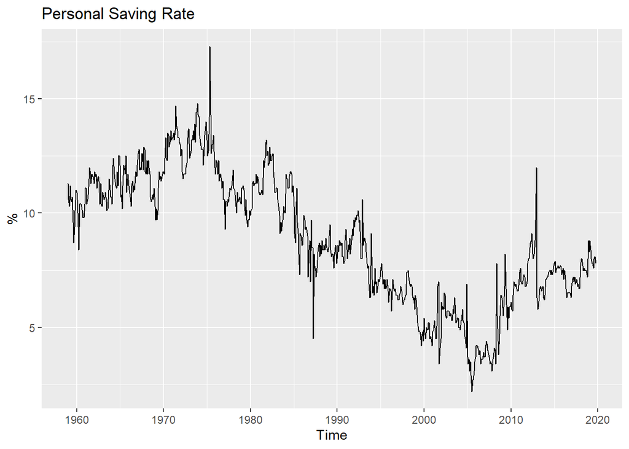

```r
PS <- ts(Savings$PSAVERT, start = 1959, frequency = 12)
autoplot(PS) + ggtitle("Personal Saving Rate") + ylab("%")
```

#### As in the previous dataset there are a lot of information that is not relevat to the present moment situation, therefore we will only use the data starting from year 2000

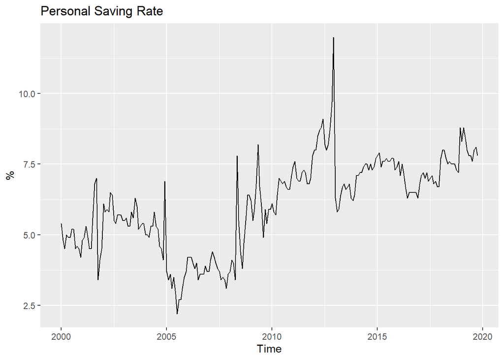

```r
PS = window(PS, start = 2000)
autoplot(PS) + ggtitle("Personal Saving Rate") + ylab("%")
```

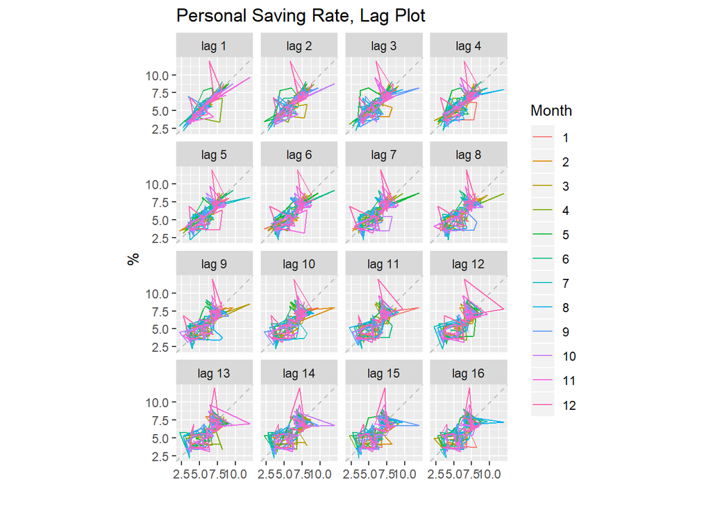

```r
gglagplot(PS) + ggtitle("Personal Saving Rate, Lag Plot") + ylab("%")
```

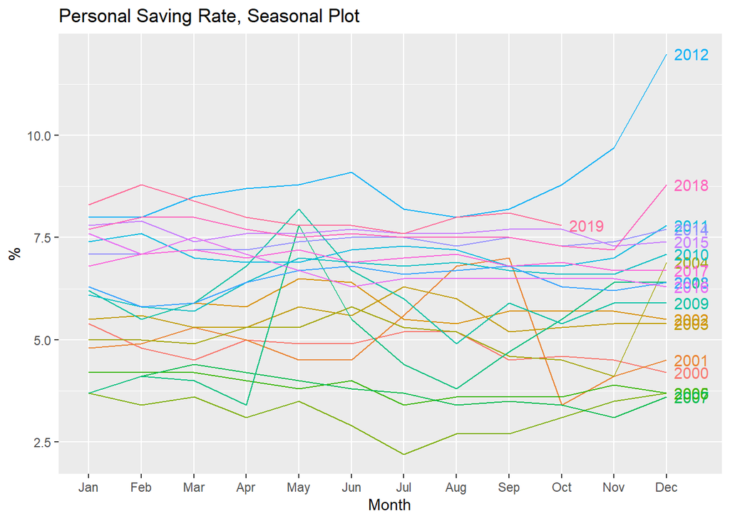

```r
ggseasonplot(PS, year.labels = T) + ggtitle("Personal Saving Rate, Seasonal Plot") + ylab("%")
```

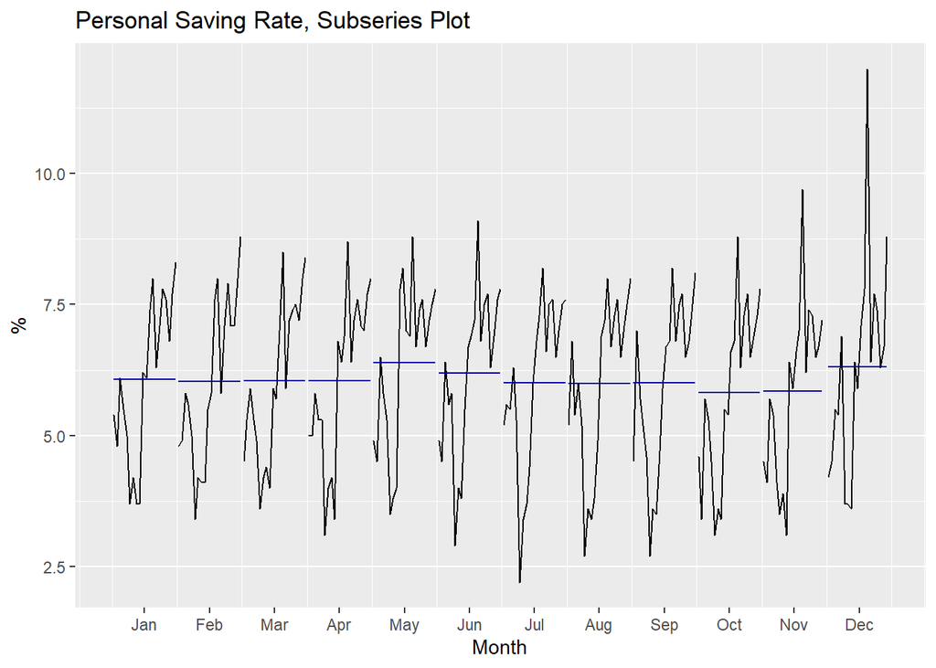

```r
ggsubseriesplot(PS) + ggtitle("Personal Saving Rate, Subseries Plot") + ylab("%")
```

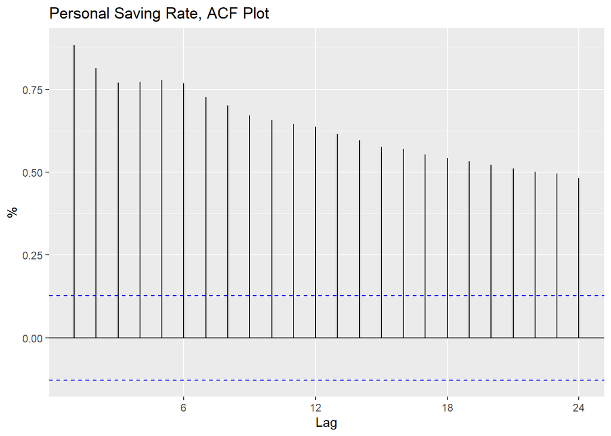

```r
ggAcf(PS) + ggtitle("Personal Saving Rate, ACF Plot") + ylab("%")
```

#### The subset appears to have an upward trend with many irregular spikes. The dataset is seasonally adjusted and Seasonal Plot shows no apparent seasonal pattern. Subseries Plot shows the average values for each month are approximately the same. The ACF Plot shows that the data is significantly correlated with the previous moths values and slowly decaying.

```r
lambda = BoxCox.lambda(PS)
lambda
```

```
## [1] 1.218374
```

#### Since the values of the data expressed as a rate the calendar and population adjustments are not appropriate. Box-Cox transformation suggested at lambda = 1.22 which is fairly close to 1 which means no mathematical transformation needed for this data either.

#### We will now consider some of the basic forecasting techniques. Seasonal naive method is not appropriate since there is no seasonality

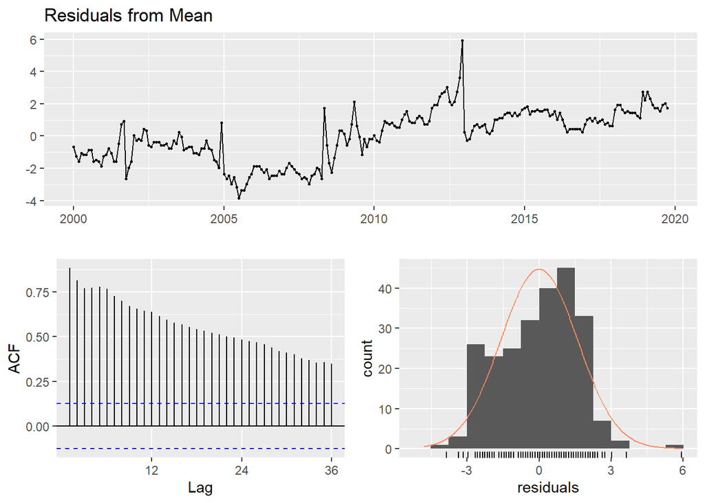

```
##
##  Ljung-Box test
##
## data:  Residuals from Mean
## Q* = 2531.9, df = 23, p-value < 2.2e-16
##
## Model df: 1.   Total lags used: 24
```

```r
PS_mean = meanf(PS, h = 24)
PS_naive = naive(PS, h = 24)
PS_rwf = rwf(PS, drift = T, h = 24)

checkresiduals(PS_mean)
```

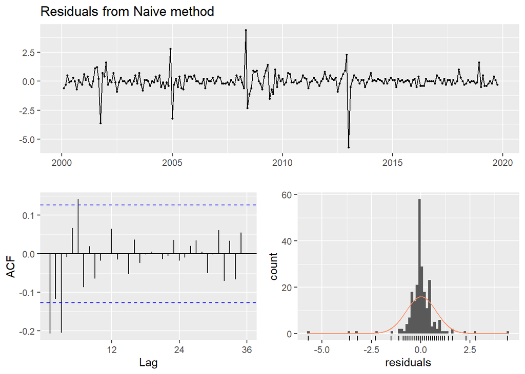

```
##
##  Ljung-Box test
##
## data:  Residuals from Naive method
## Q* = 35.741, df = 24, p-value = 0.05814
##
## Model df: 0.   Total lags used: 24
```

```r
checkresiduals(PS_naive)
```

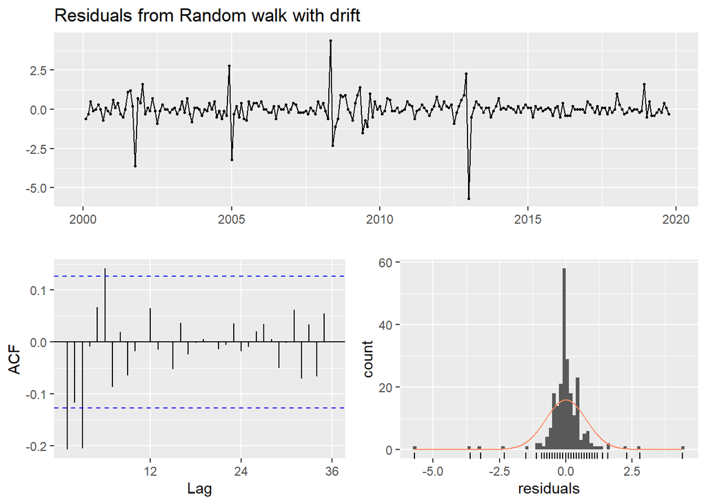

```
##
##  Ljung-Box test
##
## data:  Residuals from Random walk with drift
## Q* = 35.741, df = 23, p-value = 0.04383
##
## Model df: 1.   Total lags used: 24
```

```r
checkresiduals(PS_rwf)
```

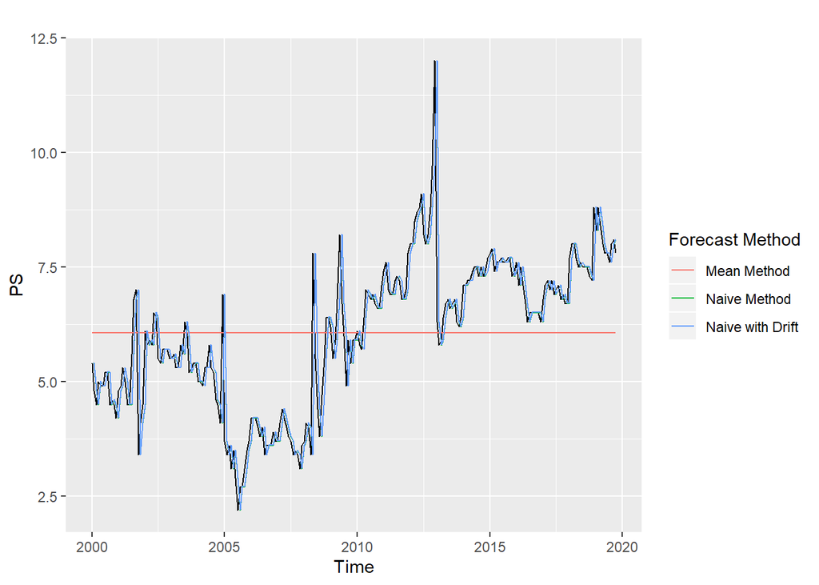

```r
autoplot(PS) +
  autolayer(fitted(PS_mean), series = "Mean Method") +
  autolayer(fitted(PS_naive), series = "Naive Method") +
  autolayer(fitted(PS_rwf), series = "Naive with Drift") +
  guides(color = guide_legend(title = "Forecast Method"))
```

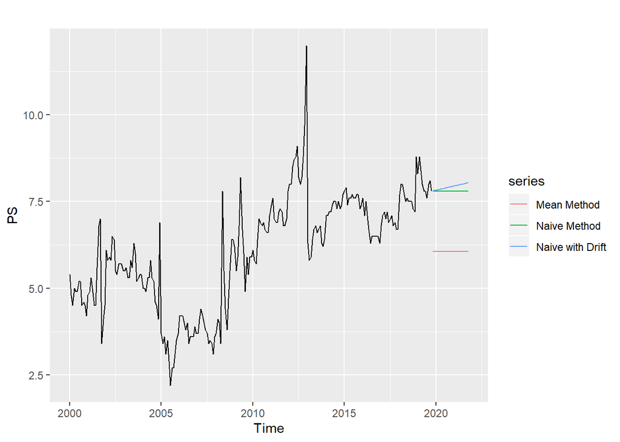

```r
autoplot(PS) +
  autolayer(PS_mean$mean, series = "Mean Method") +
  autolayer(PS_naive$mean, series = "Naive Method") +
  autolayer(PS_rwf$mean, series = "Naive with Drift")
```

#### Mean Method performs poorly due to upward trend in the data. Naive and Naive with drift methods display similar results, the residuals have some autocorrelation structure, they are centered around 0 and the distribution has heavy tails which is likely cause the autocorrelation structure.

#### Let’s check the cross validation procedure to see how methods perform on the step forecasts

```r
e_m_1 = tsCV(PS, meanf, h = 1)
sqrt(mean(e_sn_1^2, na.rm = T))
```

```
## [1] 0.7936177
```

```r
e_n_1 = tsCV(PS, rwf, h = 1)
sqrt(mean(e_n_1^2, na.rm = T))
```

```
## [1] 0.7614665
```

```r
e_rwf_1 = tsCV(PS, rwf, drift = T, h = 1)
sqrt(mean(e_rwf_1^2, na.rm = T))
```

```
## [1] 0.7703091
```

```r
e_m_12 = tsCV(PS, meanf, h = 12)
sqrt(mean(e_sn_12^2, na.rm = T))
```

```
## [1] 0.7486361
```

```r
e_n_12 = tsCV(PS, rwf, h = 12)
sqrt(mean(e_n_12^2, na.rm = T))
```

```
## [1] 1.11507
```

```r
e_rwf_12 = tsCV(PS, rwf, drift = T, h = 12)
sqrt(mean(e_rwf_12^2, na.rm = T))
```

```
## [1] 1.243181
```

#### Let’s now do the training/test split and see how these methods predict new data

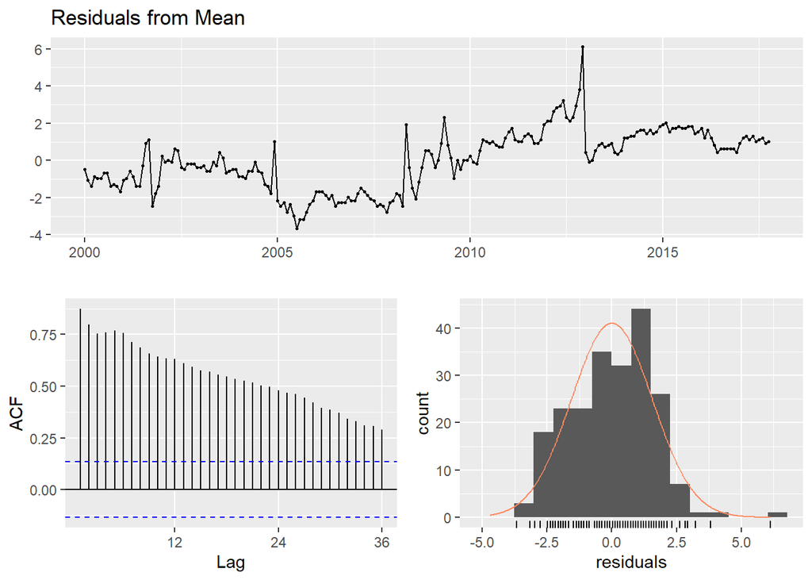

```
##
##  Ljung-Box test
##
## data:  Residuals from Mean
## Q* = 2244.1, df = 23, p-value < 2.2e-16
##
## Model df: 1.   Total lags used: 24
```

```r
PS_train = head(PS, length(PS)-24)
PS_test = tail(PS, 24)

PS_mean = meanf(PS_train, h = 24)
PS_naive = naive(PS_train, h = 24)
PS_rwf = rwf(PS_train, drift = T, h = 24)

checkresiduals(PS_mean)
```

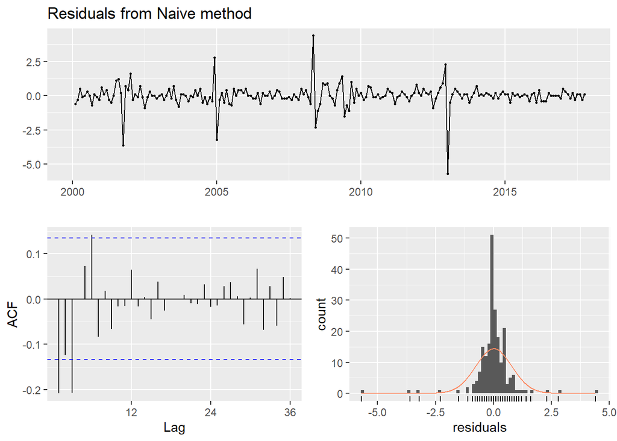

```
##
##  Ljung-Box test
##
## data:  Residuals from Naive method
## Q* = 32.712, df = 24, p-value = 0.1103
##
## Model df: 0.   Total lags used: 24
```

```r
checkresiduals(PS_naive)
```

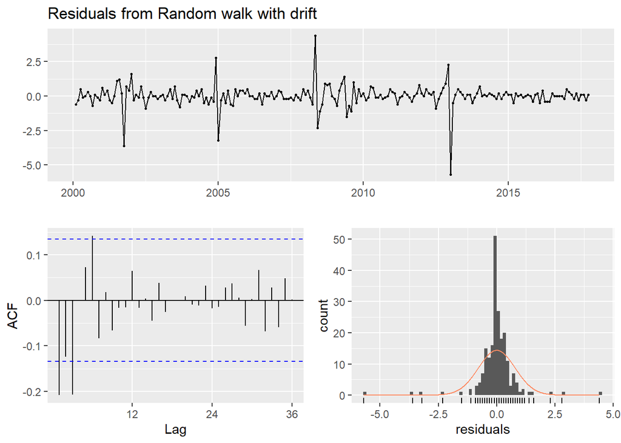

```
##
##  Ljung-Box test
##
## data:  Residuals from Random walk with drift
## Q* = 32.712, df = 23, p-value = 0.08621
##
## Model df: 1.   Total lags used: 24
```

```r
checkresiduals(PS_rwf)
```

```r
accuracy(PS_mean, PS_test)
```

```
##                        ME     RMSE      MAE       MPE     MAPE     MASE
## Training set 3.020972e-16 1.566021 1.297974 -8.602371 25.75486 1.299904
## Test set     1.889136e+00 1.957552 1.889136 24.001390 24.00139 1.891945
##                   ACF1 Theil's U
## Training set 0.8726720        NA
## Test set     0.5139274  3.993782
```

```r
accuracy(PS_naive, PS_test)
```

```
##                       ME      RMSE       MAE        MPE      MAPE
## Training set 0.007042254 0.7883244 0.4164319 -0.8340609  7.729141
## Test set     0.862500000 1.0035354 0.8958333 10.7172031 11.214715
##                   MASE       ACF1 Theil's U
## Training set 0.4170513 -0.2082521        NA
## Test set     0.8971658  0.5139274  2.034714
```

```r
accuracy(PS_rwf, PS_test)
```

```
##                         ME      RMSE       MAE        MPE      MAPE
## Training set -9.381206e-17 0.7882930 0.4169940 -0.9642759  7.748142
## Test set      7.744718e-01 0.9173035 0.8095657  9.5993432 10.123133
##                   MASE       ACF1 Theil's U
## Training set 0.4176142 -0.2082521        NA
## Test set     0.8107698  0.4860700  1.861464
```

#### We see similar residual diagnostics for the training set. Naive with Drift method predicts new data better than other methods. We will choose the Naive with Drift Method as a baseline that other models have to beat in order to be accepted.

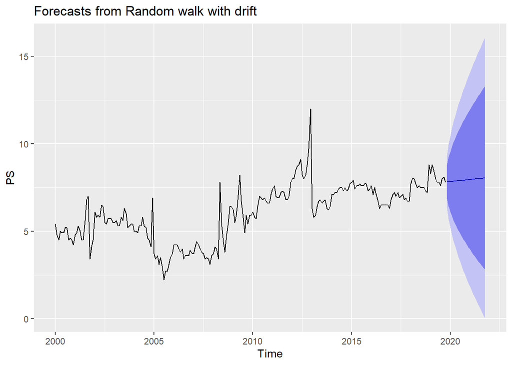

```r
PS_rwf = rwf(PS, drift = T, h = 24)
autoplot(PS_rwf)
```

#### Let’s now consider exponential smoothing methods Holt Winter’s Method is not appropriate because our data does not have seasonal patterns

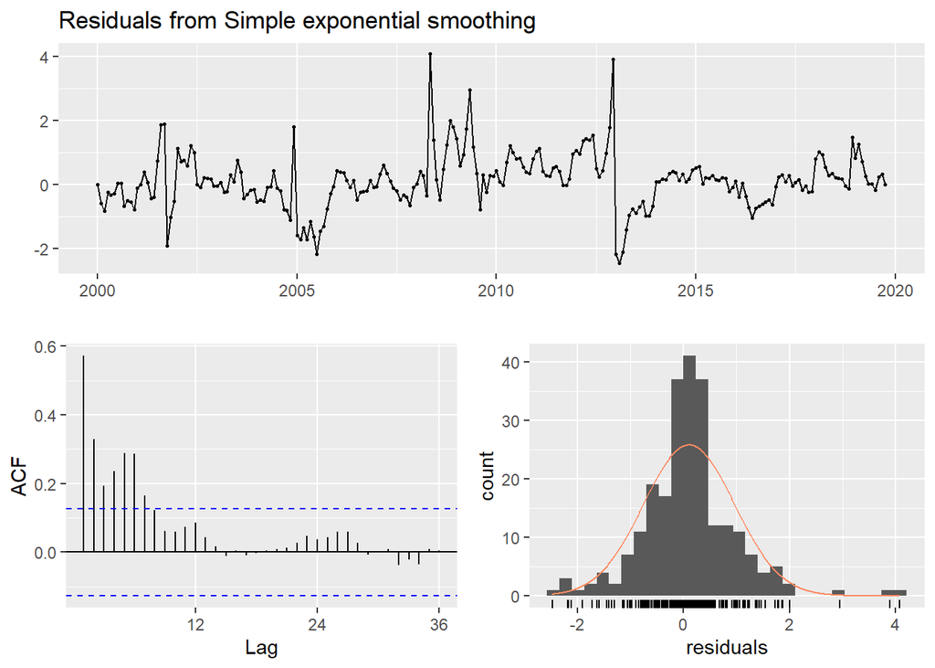

```
##
##  Ljung-Box test
##
## data:  Residuals from Simple exponential smoothing
## Q* = 185.8, df = 22, p-value < 2.2e-16
##
## Model df: 2.   Total lags used: 24
```

```r
PS_ses.1 = ses(PS, alpha = .1, initial = "simple")
PS_ses.2 = ses(PS, alpha = .2, initial = "simple")
PS_ses.4 = ses(PS, alpha = .4, initial = "simple")
PS_ses.6 = ses(PS, alpha = .6, initial = "simple")
PS_ses.8 = ses(PS, alpha = .8, initial = "simple")
PS_ses = ses(PS)

checkresiduals(PS_ses.1)
```

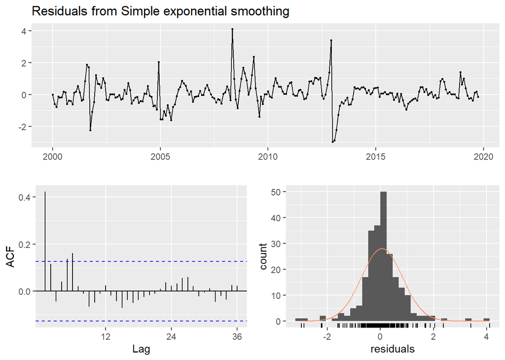

```
##
##  Ljung-Box test
##
## data:  Residuals from Simple exponential smoothing
## Q* = 64.023, df = 22, p-value = 5.566e-06
##
## Model df: 2.   Total lags used: 24
```

```r
checkresiduals(PS_ses.2)
```

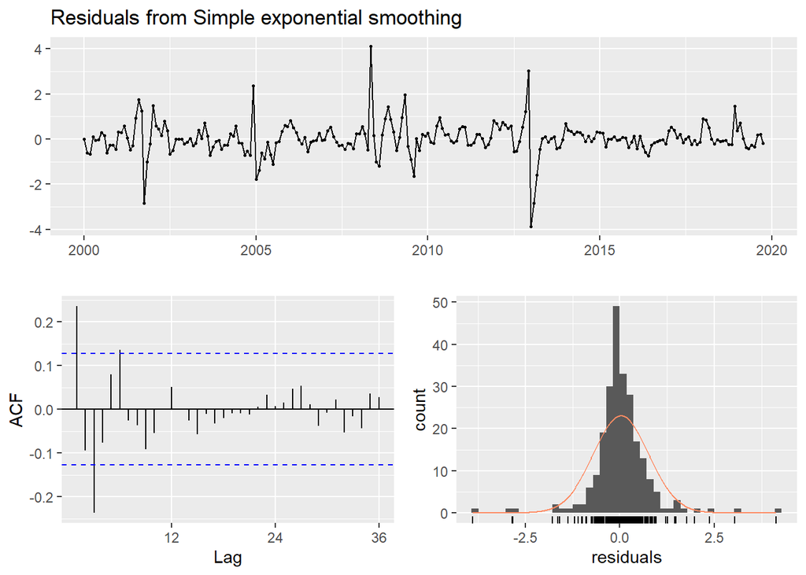

```
##
##  Ljung-Box test
##
## data:  Residuals from Simple exponential smoothing
## Q* = 42.514, df = 22, p-value = 0.005413
##
## Model df: 2.   Total lags used: 24
```

```r
checkresiduals(PS_ses.4)
```

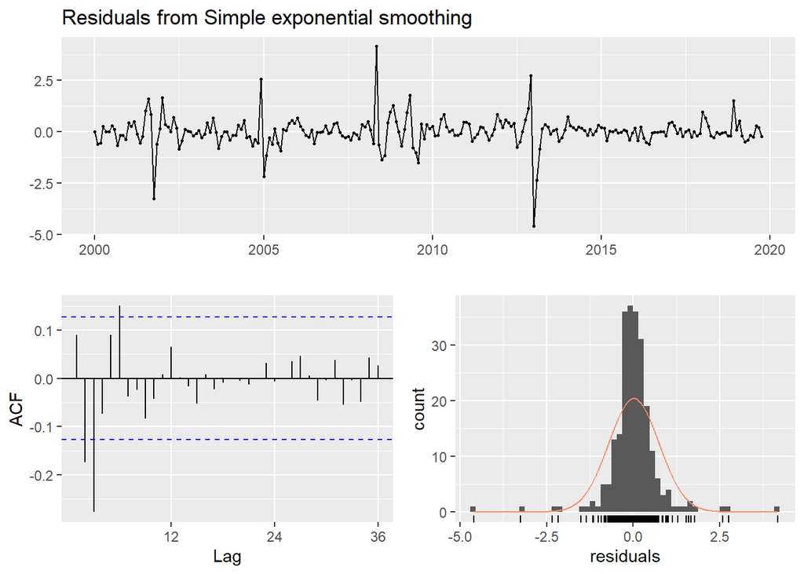

```
##
##  Ljung-Box test
##
## data:  Residuals from Simple exponential smoothing
## Q* = 41.951, df = 22, p-value = 0.006336
##
## Model df: 2.   Total lags used: 24
```

```r
checkresiduals(PS_ses.6)
```

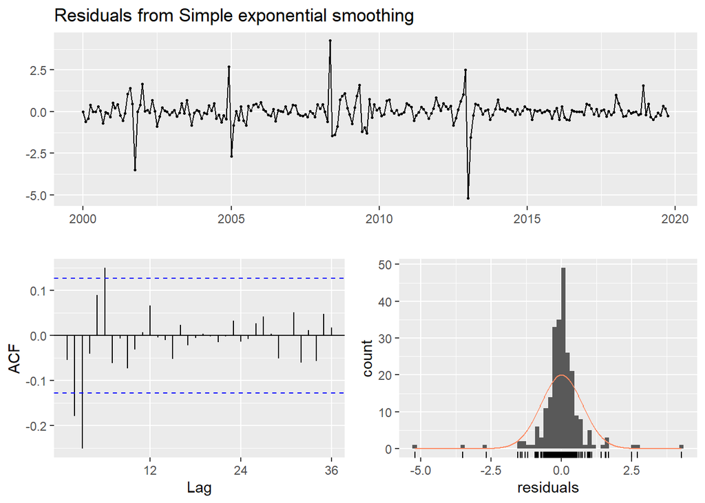

```
##
##  Ljung-Box test
##
## data:  Residuals from Simple exponential smoothing
## Q* = 36.642, df = 22, p-value = 0.02588
##
## Model df: 2.   Total lags used: 24
```

```r
checkresiduals(PS_ses.8)
```

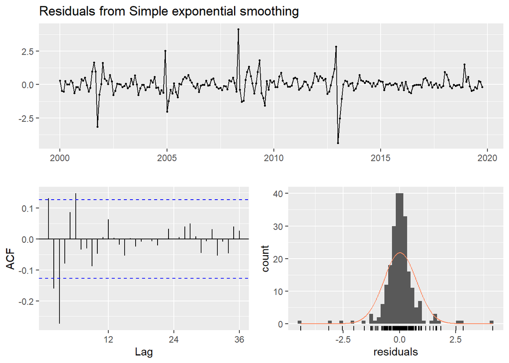

```
##
##  Ljung-Box test
##
## data:  Residuals from Simple exponential smoothing
## Q* = 42.926, df = 22, p-value = 0.00482
##
## Model df: 2.   Total lags used: 24
```

```r
checkresiduals(PS_ses)
```

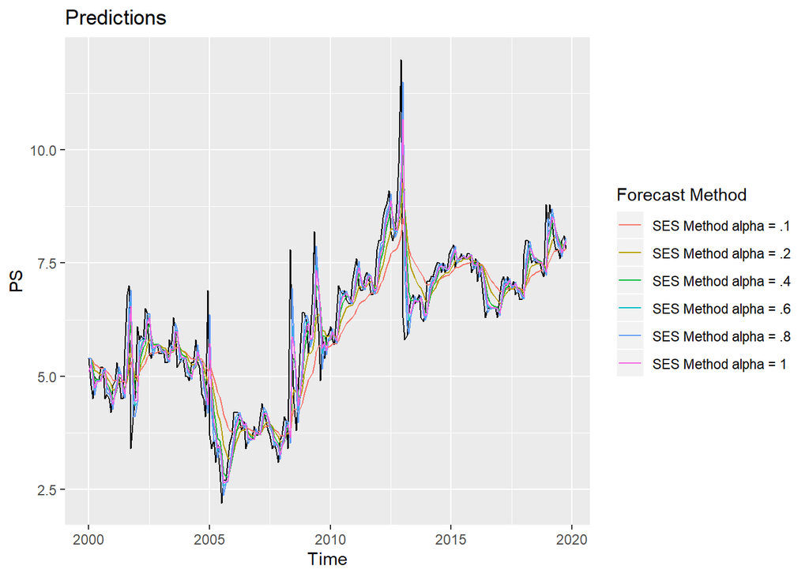

```r
autoplot(PS) + ggtitle("Predictions")+
  autolayer(fitted(PS_ses.1), series = "SES Method alpha = .1") +
  autolayer(fitted(PS_ses.2), series = "SES Method alpha = .2") +
  autolayer(fitted(PS_ses.4), series = "SES Method alpha = .4") +
  autolayer(fitted(PS_ses.6), series = "SES Method alpha = .6") +
  autolayer(fitted(PS_ses.8), series = "SES Method alpha = .8") +
  autolayer(fitted(PS_ses), series = "SES Method alpha = 1") +
  guides(color = guide_legend(title = "Forecast Method"))
```

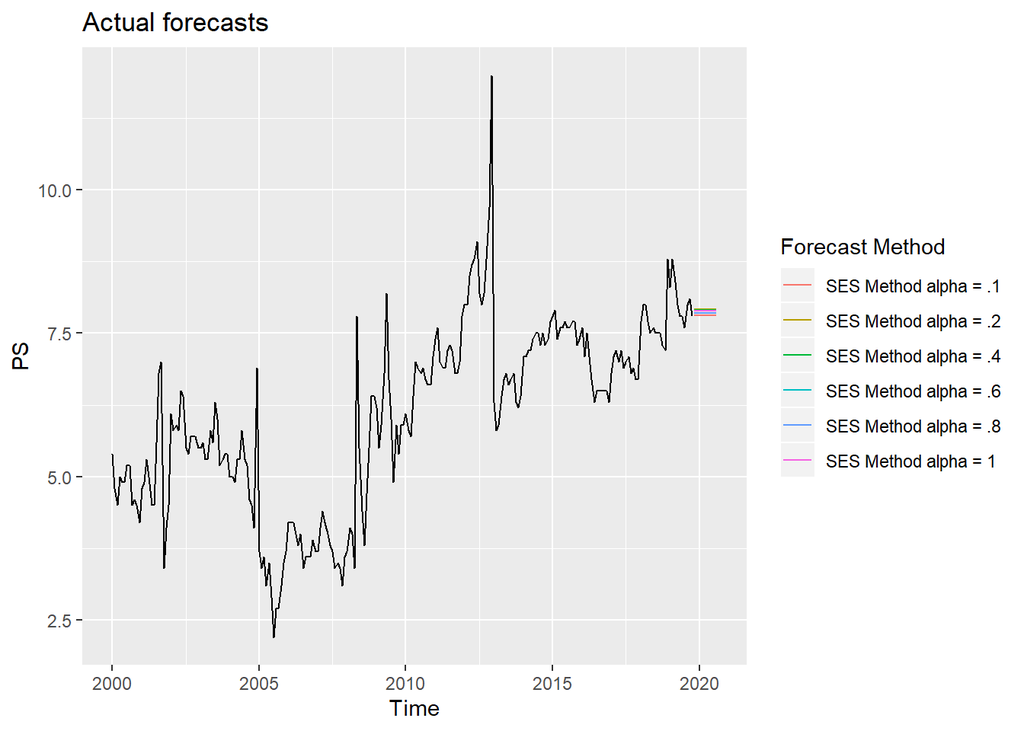

```r
autoplot(PS) + ggtitle("Actual forecasts")+
  autolayer(PS_ses.1$mean, series = "SES Method alpha = .1") +
  autolayer(PS_ses.2$mean, series = "SES Method alpha = .2") +
  autolayer(PS_ses.4$mean, series = "SES Method alpha = .4") +
  autolayer(PS_ses.6$mean, series = "SES Method alpha = .6") +
  autolayer(PS_ses.8$mean, series = "SES Method alpha = .8") +
  autolayer(PS_ses$mean, series = "SES Method alpha = 1") +
  guides(color = guide_legend(title = "Forecast Method"))
```

#### SES with alpha = 0.1 has autocorrelation problem and big areas of under and overestimation. Other models roughly satisfy the assumptions.

#### Let’s now consider the Holt’s Linear Trend Method, damped and non-damped.

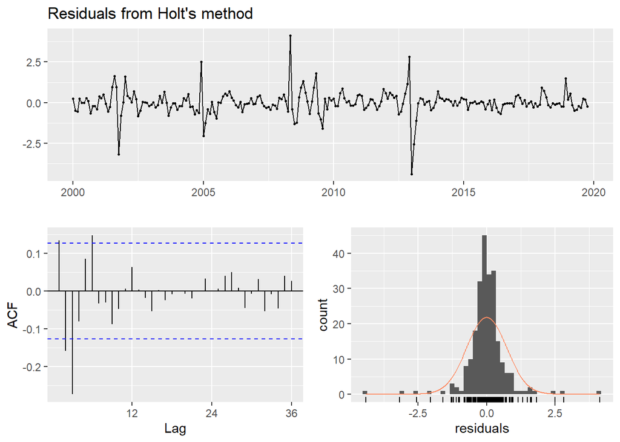

```
##
##  Ljung-Box test
##
## data:  Residuals from Holt's method
## Q* = 42.919, df = 20, p-value = 0.002095
##
## Model df: 4.   Total lags used: 24
```

```r
PS_holt = holt(PS)
PS_holt_d = holt(PS, damped = T)

checkresiduals(PS_holt)
```

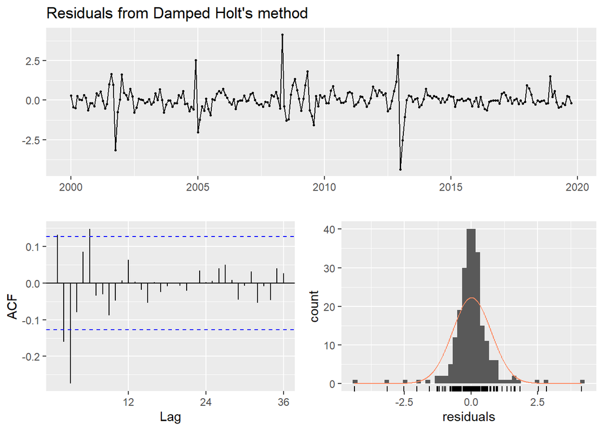

```
##
##  Ljung-Box test
##
## data:  Residuals from Damped Holt's method
## Q* = 42.959, df = 19, p-value = 0.001313
##
## Model df: 5.   Total lags used: 24
```

```r
checkresiduals(PS_holt_d)
```

#### Both Holt’s Linear Trend Methods equally satisfy the assumptions. Residuals are centered around 0 and are normally distributed, although with several outliers.

#### Let’s evaluate the performance of these models on new data

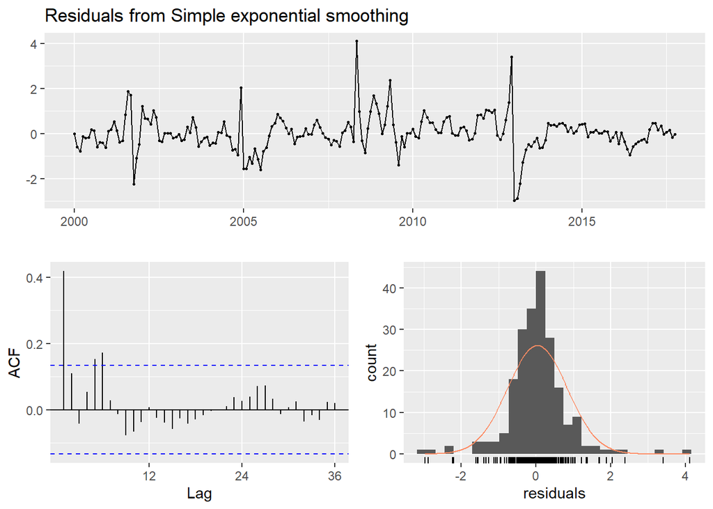

```
##
##  Ljung-Box test
##
## data:  Residuals from Simple exponential smoothing
## Q* = 59.036, df = 22, p-value = 3.1e-05
##
## Model df: 2.   Total lags used: 24
```

```r
PS_ses.2 = ses(PS_train, alpha = .2, initial = "simple")
PS_ses.4 = ses(PS_train, alpha = .4, initial = "simple")
PS_ses.6 = ses(PS_train, alpha = .6, initial = "simple")
PS_ses.8 = ses(PS_train, alpha = .8, initial = "simple")
PS_ses = ses(PS_train)
PS_holt = holt(PS_train)
PS_holt_d = holt(PS_train, damped = T)

checkresiduals(PS_ses.2)
```

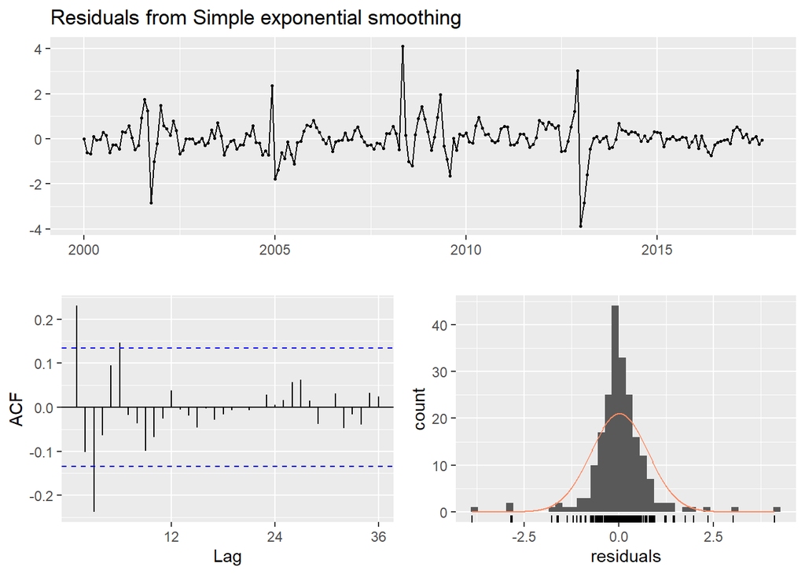

```
##
##  Ljung-Box test
##
## data:  Residuals from Simple exponential smoothing
## Q* = 38.997, df = 22, p-value = 0.01412
##
## Model df: 2.   Total lags used: 24
```

```r
checkresiduals(PS_ses.4)
```

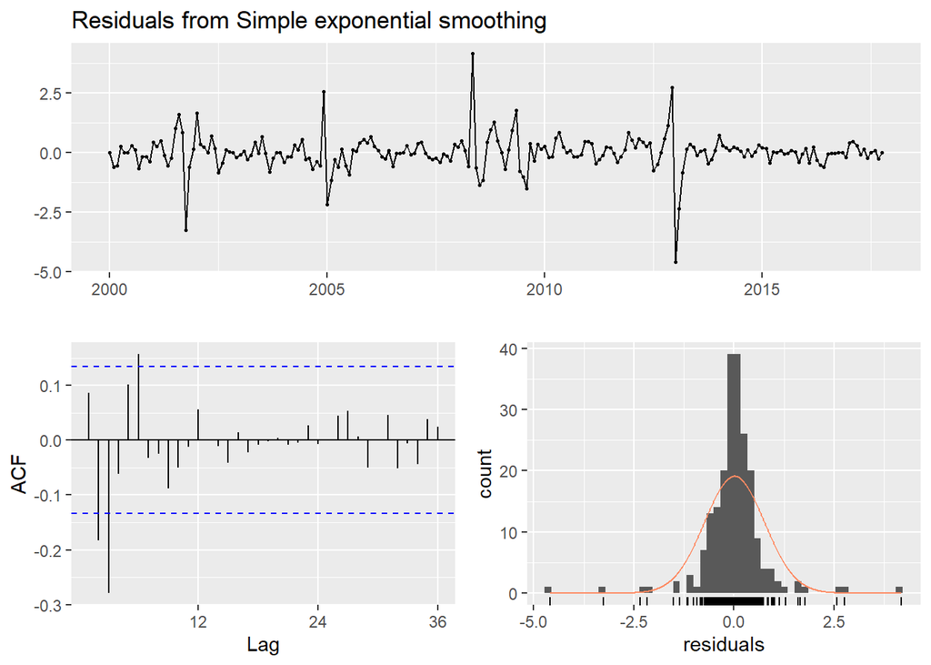

```
##
##  Ljung-Box test
##
## data:  Residuals from Simple exponential smoothing
## Q* = 38.791, df = 22, p-value = 0.01491
##
## Model df: 2.   Total lags used: 24
```

```r
checkresiduals(PS_ses.6)
```

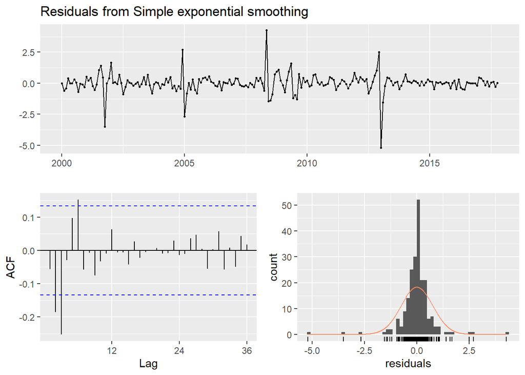

```
##
##  Ljung-Box test
##
## data:  Residuals from Simple exponential smoothing
## Q* = 33.914, df = 22, p-value = 0.05012
##
## Model df: 2.   Total lags used: 24
```

```r
checkresiduals(PS_ses.8)
```

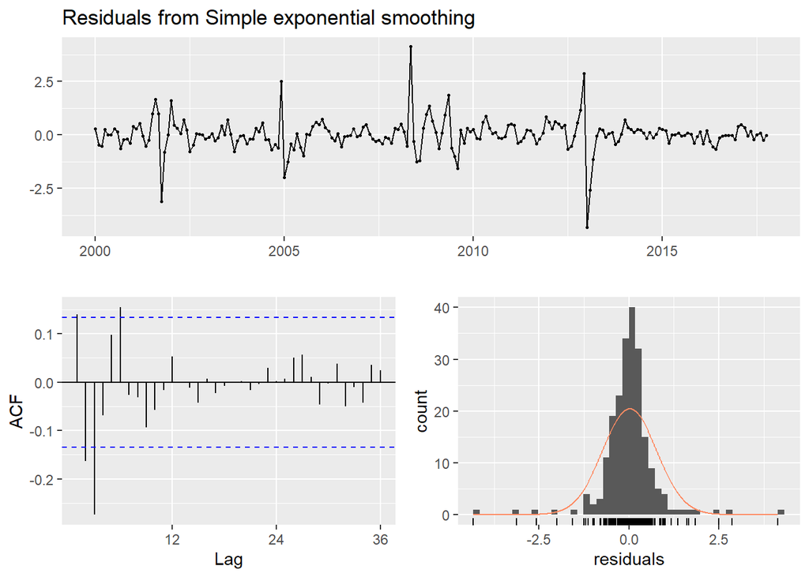

```
##
##  Ljung-Box test
##
## data:  Residuals from Simple exponential smoothing
## Q* = 39.638, df = 22, p-value = 0.01191
##
## Model df: 2.   Total lags used: 24
```

```r
checkresiduals(PS_ses)
```

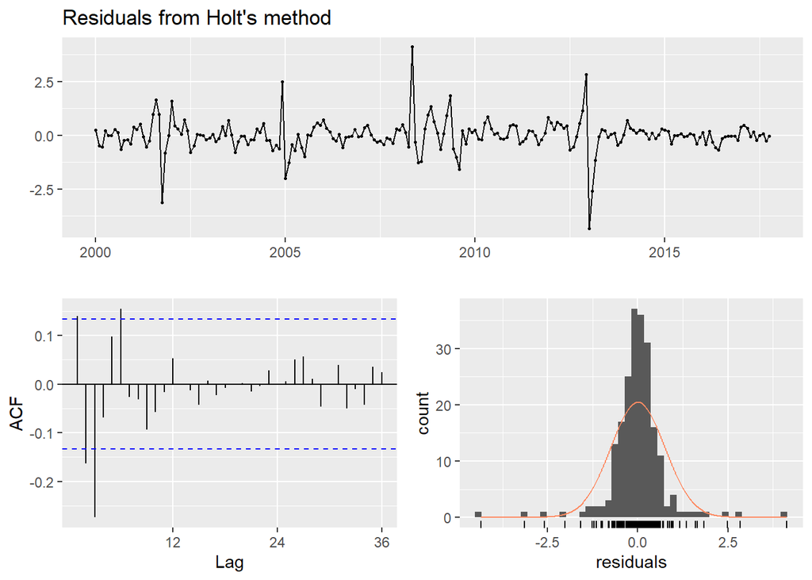

```
##
##  Ljung-Box test
##
## data:  Residuals from Holt's method
## Q* = 39.612, df = 20, p-value = 0.00559
##
## Model df: 4.   Total lags used: 24
```

```r
checkresiduals(PS_holt)
```

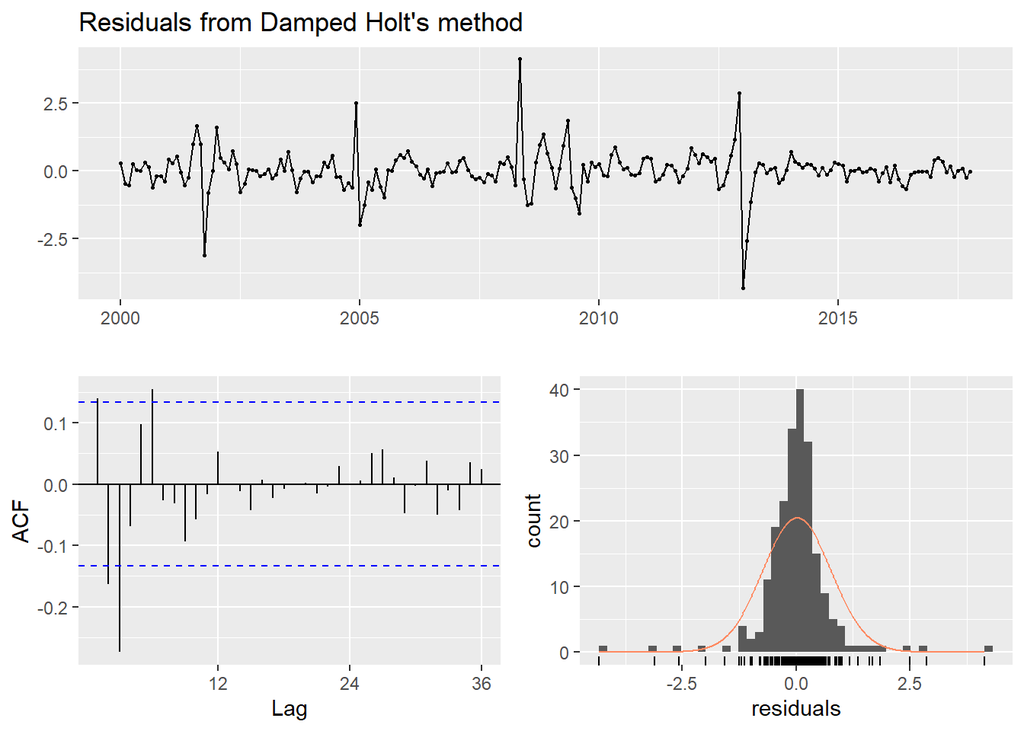

```
##
##  Ljung-Box test
##
## data:  Residuals from Damped Holt's method
## Q* = 39.648, df = 19, p-value = 0.003638
##
## Model df: 5.   Total lags used: 24
```

```r
checkresiduals(PS_holt_d)
```